# Explore and Summarize Data UDACITY TERM 2 PROJECT 2

# Multivariate Analysis

### Talk about some of the relationships you observed in this part of the investigation. Were there features that strengthened each other in terms of looking at your feature(s) of interest?

The three most influential features (*alcohol*, *citric.acid* and *volatile.acidity*) strengthen each other: the bulk of high quality wines are in the medium-high range in *alcohol* and *citric.acid* quantity, and their *volatile.acidity* is in the medium-low range. The ones with the highest quality (eight) tend to concentrate even more on the extremes. The opposite situation happens with bad quality wines.

### Were there any interesting or surprising interactions between features?

It looks like very high *volatile.acidity* values almost completely prevent a wine to achieve a high quality rating. There are some high rated wines with very low citric acid and alcohol content, and even with a slightly high volatile acidity (around 0.8), but higher than that there are almost none.

It is like there is a threshold at approximately 0.8-0.9 g/dm<sup>3</sup> of acetic acid from which the unpleasant vinegar taste, described by the authors of the dataset, is noted.

# Final Plots and Summary

### Plot One

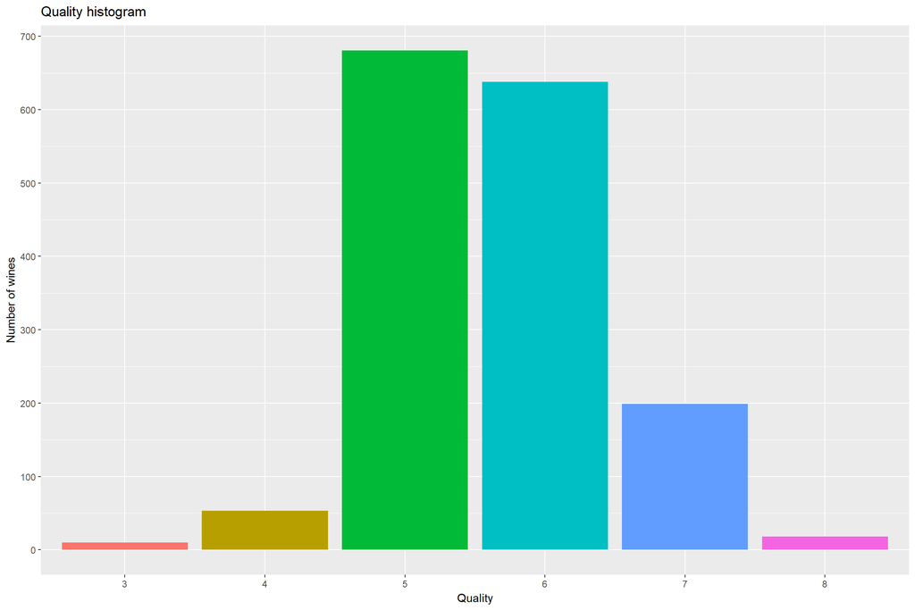

### Description One

A very big majority of wines are of quality five or six: 681 + 638 of a total of 1599, i.e. approximately 82.5% of the wines. There are very few of quality three or eight (10 and 18, respectively), and no wine achieves a more extreme quality rating: of a scale of zero to ten, there are no wines with a quality rating of zero, one, two, nine or ten.

This is probably due to the way the wines are rated. According to the information provided by the authors: “the output is based on sensory data (median of at least 3 evaluations made by wine experts)”. Unfortunately, we do not have the individual evaluations for each wine, so we cannot know how dispersed are these.

### Plot Two

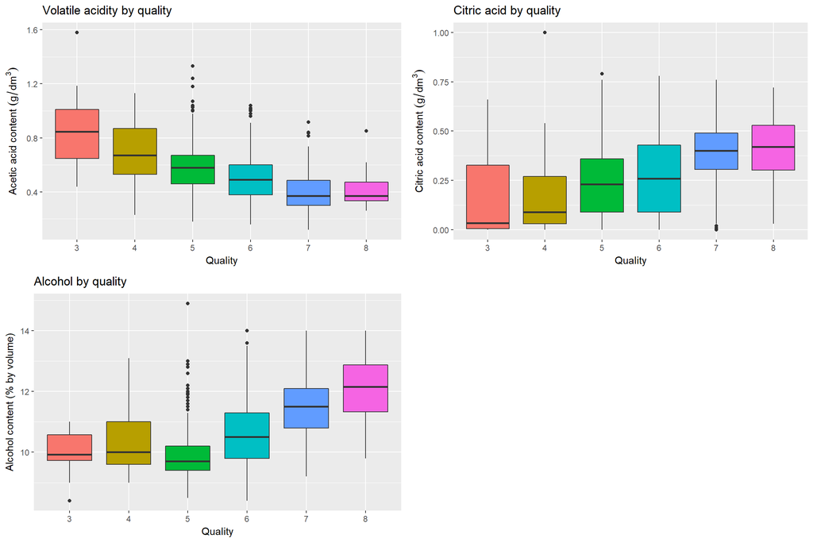

### Description Two

Boxplots of what the data suggest are the three most influential features, colored by each one of the six quality ratings. All these features have a weak or moderate correlation with quality, but are not linear: they seem to flatten for the highest quality wines (*volatile.acidity*, *citric.acid*) or the lowest (*alcohol*).

In fact, the median *volatile.acidity* of wines of quality seven and eight is exactly the same (0.37) and the inter-quartile range is similar (0.185 and 0.1375). A similar situation happens with *citric.acid*: medians of 0.4 and 0.42, IQRs of 0.185 and 0.2275. In the case of *alcohol*, wines of quality below six share similar median values of alcohol content (9.925, 10, 9.7), and the IQRs of wines of quality three and five are also similar (0.85, 0.8), although for wines of quality four is more dispersed (1.4)

In all the plots, every box overlaps horizontally at least with the ones on the left and right. Since boxes delimit the first and third quartiles, that comprise half of the observations in a normal distribution, this shows that none of these features alone can be used to accurately predict quality.

### Plot Three

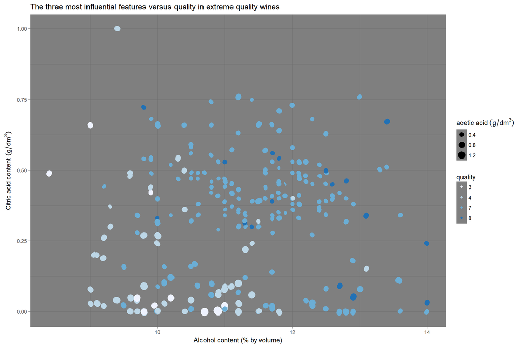

### Description Three

*Quality* and the three most influential variables visualized together in one plot. Wines of quality five or six are not displayed in order to avoid excessive clutter.

The plots show that the bulk of the high quality wines tend to favor low volatile acidity and high citric acid and alcohol, while the opposite happens with low quality wines. The plot also shows that the different colors and sizes are not completely separated, which indicates that no combination of these three features can fully explain *quality*, which is expected, being the quality of a wine a rather subjective feature.

It is also worth mentioning that the plot suggests that very high values of acetic acid almost always prevents a wine from achieving a high quality rating: there are a few highly rated wines with very low alcohol and citric acid content, but none with very high volatile acidity.

In fact, the maximum acetic acid content found in wines of quality seven and eight is 0.915 and 0.85 g/dm<sup>3</sup> respectively. Following a [common criteria](https://en.wikipedia.org/wiki/Interquartile_range#Interquartile_range_and_outliers) for identifying outliers (observations that fall below Q1 - 1.5 * IQR or above Q3 + 1.5 * IQR), these values are clearly outliers within their quality group (above 0.7625 and 0.67875, respectively) but not within the whole *volatile.acidity* distribution (below 1.015).

# Reflection

I was initially surprised by the seemingly dispersed nature of the wine data. Nothing was immediately correlatable to being an inherant quality of good wines. However, upon reflection, this is a sensible finding. Wine making is still something of a science and an art, and if there was one single property or process that continually yielded high quality wines, the field wouldn’t be what it is.

I was surprised to find that alcohol content and citric acid were the most correlatable properties to wine quality. as per i thought, sulphates and acidity were what I assumed would be the main correlations.

Additionally, having the wine type would be helpful for further analysis. Somalliers might prefer certain types of wines to have different properties and behaviors. For example, a Port (as sweet desert wine) surely is rated differently from a dark and robust abernet Sauvignon, which is rated differently from a bright and fruity Syrah. Without knowing the type of wine, it is entirely possible that we are almost literally comparing apples to oranges and can’t find a correlation.

In the future, I would like to do some research into the wine making process. Some winemakers might actively try for some property values or combinations, and finding those combinations (of 3 or more properties) might be the key to truly predicting wine quality. This investigation was not able to find a strong set of two properties that would consistently be able to predict wine quality with any degree of certainty.